# act_report

## Report: act_report

## Project: Wrangle and Analyze Data

In the above report, insights on the wrangled data will be communicated and displayed visual. The aim of the report is to answer the following question;

- Which is the most favorite and retweeted dog?
- What is the relationship of dog stage to receive retweets?
- What is the relationship of dog stage to favorite count?
- What is the correlation between tweets with higher ratings and the favorite?
- What is the correlation between the retweets and the favorite?

### Question 1: Which is the most favorite and retweeted dog?

To answer, the he dog that receive the most number of retweet count and have the highest number of count was reviewed. The highest number of fovorite count was found 141,453 and the highest number of retweet count was 69,230. Ironically, the dog with highest number of like was the same dog with the highest number of retweets. The name of the dog was missing but the dogs stage was Doggo on 2016-06-18.

### Question 2: What is the relationship of dog stage to receive retweets?

The order of dog stage in accordance to the retweets;  
doggofloofer < floofer < doggopupper < doggopuppo < pupper < puppo < doggo

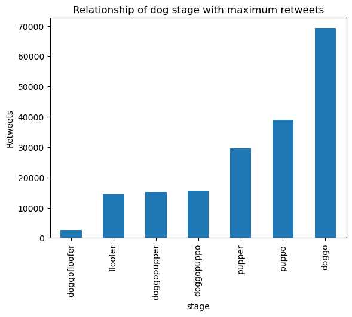

### Question 3: What is the relationship of dog stage to favorite count?

From the data the order of the dog stage receiving the number of likes in the following order; doggofloofer < floofer < doggopuppo < doggopupper < pupper < puppo < doggo. The dog stage doggofloofer receive the lowest number of likes followed by floofer, doggopuppo, doggopupper, pupper then puppo and lastly doggo receive the highest likes.

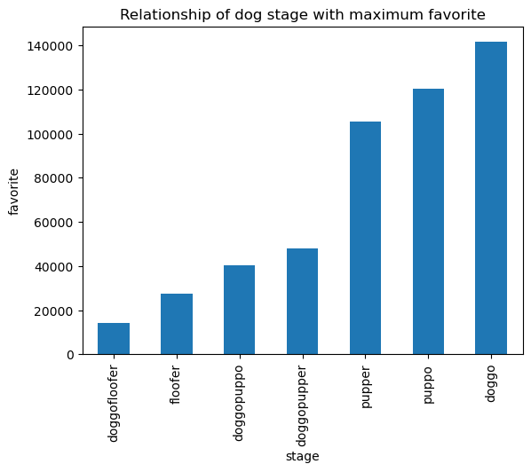

### Question 4: What is the correlation between tweets with higher ratings and the favorite?

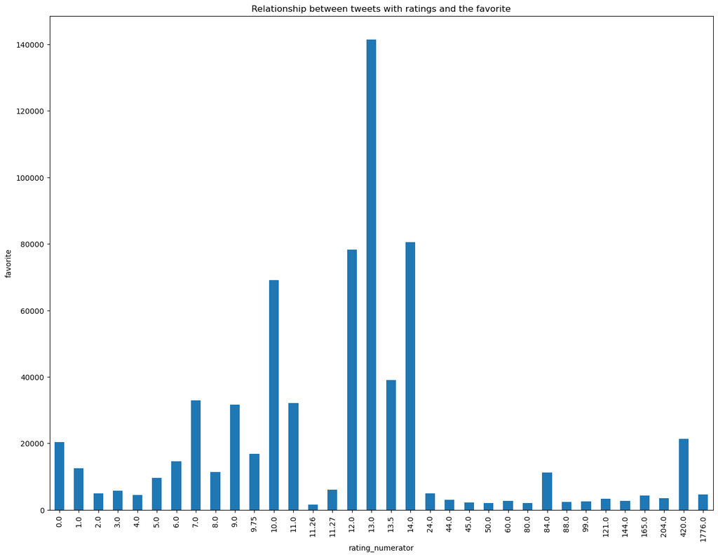

### Question 5: What is the correlation between the retweets and the favorite?

There is a positive correlation between the retweets and the favorite; the number of reweets increasing as the likes increases. This means a dog that receive a high number of likes will most likely receive a high nimber of retweets with example as the dog stage doggo that receive both the highest number of retweets and likes.

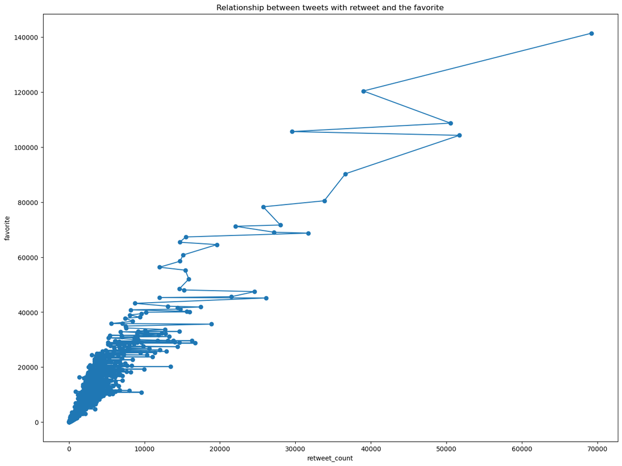